# Detecção de fraude em transações de cartão de crédito

[output not shown]

[output cut: 137 more lines]

[output not shown]

```
[I 2023-10-18 03:17:27,042] Trial 79 finished with value: 0.9 and parameters: {'n_estimators': 159, 'num_leaves': 19, 'max_depth': 27, 'learning_rate': 0.0066793520012611894, 'subsample': 0.9811964659446226, 'min_child_weight': 4, 'lambda_l1': 1.5265562042694504e-06, 'lambda_l2': 0.00306082116104662…
[I 2023-10-18 03:17:27,200] Trial 80 finished with value: 0.85 and parameters: {'n_estimators': 153, 'num_leaves': 11, 'max_depth': 34, 'learning_rate': 0.00463336418574669, 'subsample': 0.9694640133850683, 'min_child_weight': 8, 'lambda_l1': 2.472135884073951e-06, 'lambda_l2': 0.0005824703864408477…
```

[output not shown]

[output cut: 220 more lines]

[output not shown]

```
[I 2023-10-18 03:17:27,347] Trial 81 finished with value: 0.925 and parameters: {'n_estimators': 114, 'num_leaves': 20, 'max_depth': 41, 'learning_rate': 0.008567601277555834, 'subsample': 0.9403856272380655, 'min_child_weight': 5, 'lambda_l1': 4.048487420629378e-06, 'lambda_l2': 0.00028547257857545…
[I 2023-10-18 03:17:27,482] Trial 82 finished with value: 0.9125 and parameters: {'n_estimators': 143, 'num_leaves': 22, 'max_depth': 38, 'learning_rate': 0.007841136629803236, 'subsample': 0.9399688622927305, 'min_child_weight': 5, 'lambda_l1': 3.8195969134172086e-06, 'lambda_l2': 0.000386827252585…
```

[output not shown]

[output cut: 106 more lines]

[output not shown]

[output not shown]

[output cut: 191 more lines]

[output not shown]

[output not shown]

[output cut: 99 more lines]

[output not shown]

```
[I 2023-10-18 03:17:28,056] Trial 86 finished with value: 0.8875 and parameters: {'n_estimators': 112, 'num_leaves': 14, 'max_depth': 45, 'learning_rate': 0.006699417440007089, 'subsample': 0.988792224788883, 'min_child_weight': 6, 'lambda_l1': 4.580914342559408e-06, 'lambda_l2': 0.00211112093530617…
[I 2023-10-18 03:17:28,240] Trial 87 finished with value: 0.925 and parameters: {'n_estimators': 138, 'num_leaves': 17, 'max_depth': 40, 'learning_rate': 0.004953991466599352, 'subsample': 0.9564507423022808, 'min_child_weight': 5, 'lambda_l1': 6.838549631420261e-06, 'lambda_l2': 0.00025985442420910…
```

[output not shown]

[output cut: 107 more lines]

[output not shown]

[output not shown]

[output cut: 97 more lines]

[output not shown]

[output not shown]

[output cut: 155 more lines]

[output not shown]

[output not shown]

[output cut: 180 more lines]

[output not shown]

```
[I 2023-10-18 03:17:29,079] Trial 92 finished with value: 0.9125 and parameters: {'n_estimators': 152, 'num_leaves': 19, 'max_depth': 37, 'learning_rate': 0.005962535521271888, 'subsample': 0.965281394883039, 'min_child_weight': 5, 'lambda_l1': 5.9932339982061834e-06, 'lambda_l2': 0.0004437257389959…
```

[output not shown]

[output not shown]

[output cut: 159 more lines]

[output not shown]

[output not shown]

[output cut: 104 more lines]

[output not shown]

```
[I 2023-10-18 03:17:29,766] Trial 95 finished with value: 0.9 and parameters: {'n_estimators': 125, 'num_leaves': 20, 'max_depth': 40, 'learning_rate': 0.007262564329443067, 'subsample': 0.974560155853786, 'min_child_weight': 6, 'lambda_l1': 1.624404157387591e-06, 'lambda_l2': 0.0042489096863963585}…
```

[output not shown]

[output cut: 92 more lines]

[output not shown]

[output not shown]

[output cut: 72 more lines]

[output not shown]

[output not shown]

[output cut: 73 more lines]

[output not shown]

[output not shown]

## Treinando o modelo

- Utilizando os melhores parâmetros obtidos

```python
# Criando o modelo com os melhores parâmetros encontrados
modelo_under = LGBMClassifier(**melhores_hiperparametros_under)

# Treinando o modelo com os dados de Undersampling
modelo_under.fit(X_train_undersampled, y_train_undersampled)
```

[output not shown]

[output cut: 96 more lines]

[output not shown]

```
LGBMClassifier(lambda_l1=2.013838835210629e-06, lambda_l2=0.0007771472931457983,
               learning_rate=0.007551211447829674, max_depth=41,
               min_child_weight=5, n_estimators=140, num_leaves=29,
               subsample=0.8750804543836551)
```

```python
# Coletando os resultados da previsão
y_pred_undersampled = modelo_under.predict(X_test_undersampled)
```

```
[LightGBM] [Warning] lambda_l1 is set=2.013838835210629e-06, reg_alpha=0.0 will be ignored. Current value: lambda_l1=2.013838835210629e-06
[LightGBM] [Warning] lambda_l2 is set=0.0007771472931457983, reg_lambda=0.0 will be ignored. Current value: lambda_l2=0.0007771472931457983
```

## Resultados com Undersampling

- Com base nas métricas de Acurácia, Precision, Recall e F1-Score e na matriz de confusão, para os dados de Undersampling, pode-se concluir que **o modelo aprendeu a classificar transações corretamente!**

```python
# Coletando as métricas de classificação obtidas
metricas = classification_report(y_test_undersampled, y_pred_undersampled)
print(metricas)
```

```
              precision    recall  f1-score   support

           0       0.92      0.95      0.93        74
           1       0.95      0.93      0.94        80

    accuracy                           0.94       154
   macro avg       0.93      0.94      0.94       154
weighted avg       0.94      0.94      0.94       154
```

### Matriz de confusão

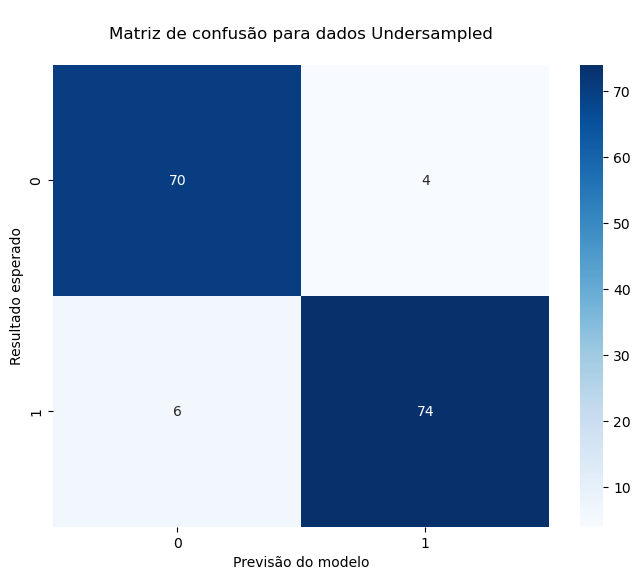

```python
matrix = confusion_matrix(y_test_undersampled, y_pred_undersampled)
plt.figure(figsize=(8, 6))
sns.heatmap(matrix, annot=True, fmt="d", cmap="Blues")
plt.xlabel('Previsão do modelo')
plt.ylabel('Resultado esperado')
plt.title('\nMatriz de confusão para dados Undersampled\n')
plt.show()
```

# Dados do Oversampling

### Split nos dados

```python
X_train_oversampled, X_test_oversampled, y_train_oversampled, y_test_oversampled = train_test_split(X_oversampled, y_oversampled, test_size=0.2, random_state=21)

print('Describe de treino:')
display(X_train_oversampled.describe())

print('\nDescribe de teste:')
display(X_test_oversampled.describe())

print('\nDistribuição de fraude na base de treino:')
display(y_train_oversampled.to_frame()['Class'].value_counts())
display(y_train_oversampled.to_frame()['Class'].value_counts(1))

print('\nDistribuição de fraude na base de teste:')
display(y_test_oversampled.to_frame()['Class'].value_counts())
display(y_test_oversampled.to_frame()['Class'].value_counts(1))
```

```
Describe de treino:
```

|  | V1 | V2 | V3 | V4 | V5 | V6 | V7 | V8 | V9 | V10 | ... | V21 | V22 | V23 | V24 | V25 | V26 | V27 | V28 | Time_scaled | Amount_scaled |
| --- | --- | --- | --- | --- | --- | --- | --- | --- | --- | --- | --- | --- | --- | --- | --- | --- | --- | --- | --- | --- | --- |
| count | 363939.000000 | 363939.000000 | 363939.000000 | 363939.000000 | 363939.000000 | 363939.000000 | 363939.000000 | 363939.000000 | 363939.000000 | 363939.000000 | ... | 363939.000000 | 363939.000000 | 363939.000000 | 363939.000000 | 363939.000000 | 363939.000000 | 363939.000000 | 363939.000000 | 363939.000000 | 363939.000000 |
| mean | -2.404933 | 1.878857 | -3.534989 | 2.260561 | -1.628606 | -0.731397 | -2.853631 | 0.326825 | -1.303156 | -2.892411 | ... | 0.450927 | -0.029360 | 0.024533 | -0.051693 | 0.047915 | 0.017700 | 0.092641 | 0.053988 | 0.013025 | 0.993551 |
| std | 5.638260 | 3.759554 | 6.309037 | 3.141433 | 4.244152 | 1.719986 | 5.837551 | 5.029557 | 2.292661 | 4.546144 | ... | 2.942064 | 1.194509 | 0.888467 | 0.541842 | 0.611314 | 0.448488 | 0.991765 | 0.428524 | 0.539853 | 3.231968 |
| min | -56.407510 | -72.715728 | -48.325589 | -5.600607 | -113.743307 | -26.160506 | -43.557242 | -50.943369 | -13.434066 | -24.588262 | ... | -22.889347 | -10.933144 | -36.666000 | -2.836627 | -8.696627 | -2.604551 | -9.793568 | -15.430084 | -0.994197 | -0.307692 |
| 25% | -2.892902 | -0.123841 | -5.073751 | -0.071535 | -1.786741 | -1.558279 | -3.135290 | -0.185293 | -2.306596 | -4.711603 | ... | -0.156564 | -0.524164 | -0.222020 | -0.384057 | -0.290042 | -0.279640 | -0.063064 | -0.049169 | -0.432551 | -0.277677 |
| 50% | -0.736215 | 1.001466 | -1.391565 | 1.363570 | -0.454020 | -0.693902 | -0.660562 | 0.161672 | -0.692027 | -0.882357 | ... | 0.167892 | 0.015634 | -0.036477 | 0.003133 | 0.053346 | -0.025029 | 0.048589 | 0.037574 | -0.084400 | -0.031189 |
| 75% | 1.018622 | 2.807563 | 0.332659 | 4.214363 | 0.454256 | 0.012099 | 0.265575 | 0.861237 | 0.150657 | -0.000700 | ... | 0.682453 | 0.524132 | 0.178347 | 0.345122 | 0.383275 | 0.292446 | 0.470157 | 0.222585 | 0.522423 | 1.020280 |
| max | 2.446505 | 22.057729 | 4.226108 | 16.875344 | 34.801666 | 73.301626 | 120.589494 | 20.007208 | 10.392889 | 15.331742 | ... | 27.202839 | 8.361985 | 22.528412 | 4.584549 | 5.826159 | 3.517346 | 31.612198 | 33.847808 | 1.035450 | 359.009231 |

8 rows × 30 columns

```
Describe de teste:
```

|  | V1 | V2 | V3 | V4 | V5 | V6 | V7 | V8 | V9 | V10 | ... | V21 | V22 | V23 | V24 | V25 | V26 | V27 | V28 | Time_scaled | Amount_scaled |
| --- | --- | --- | --- | --- | --- | --- | --- | --- | --- | --- | --- | --- | --- | --- | --- | --- | --- | --- | --- | --- | --- |
| count | 90985.000000 | 90985.000000 | 90985.000000 | 90985.000000 | 90985.000000 | 90985.000000 | 90985.000000 | 90985.000000 | 90985.000000 | 90985.000000 | ... | 90985.000000 | 90985.000000 | 90985.000000 | 90985.000000 | 90985.000000 | 90985.000000 | 90985.000000 | 90985.000000 | 90985.000000 | 90985.000000 |
| mean | -2.396286 | 1.880639 | -3.541312 | 2.255512 | -1.626985 | -0.737132 | -2.857265 | 0.332257 | -1.307436 | -2.896073 | ... | 0.448047 | -0.027416 | 0.027016 | -0.054872 | 0.051053 | 0.018402 | 0.099151 | 0.053531 | 0.011876 | 0.976990 |
| std | 5.625844 | 3.735883 | 6.308186 | 3.146201 | 4.231322 | 1.721184 | 5.819096 | 5.030960 | 2.285681 | 4.540968 | ... | 2.935867 | 1.190283 | 0.892944 | 0.540070 | 0.611747 | 0.446986 | 0.984141 | 0.424730 | 0.539680 | 3.020380 |
| min | -37.558067 | -47.429676 | -31.103611 | -5.251492 | -35.182120 | -20.367836 | -43.514876 | -73.216718 | -13.434065 | -24.584438 | ... | -34.830382 | -8.887017 | -19.935025 | -2.732373 | -5.785255 | -1.855355 | -9.895244 | -8.424041 | -0.994150 | -0.307692 |
| 25% | -2.906842 | -0.130423 | -5.076942 | -0.079760 | -1.785555 | -1.559340 | -3.145847 | -0.184426 | -2.317096 | -4.715008 | ... | -0.157734 | -0.519178 | -0.221432 | -0.389817 | -0.287905 | -0.276636 | -0.061239 | -0.048916 | -0.433021 | -0.276788 |
| 50% | -0.733467 | 0.998563 | -1.400956 | 1.350581 | -0.456095 | -0.704408 | -0.668369 | 0.161126 | -0.707695 | -0.884654 | ... | 0.167459 | 0.015759 | -0.036013 | 0.001213 | 0.056076 | -0.024212 | 0.050230 | 0.037435 | -0.084631 | -0.033986 |
| 75% | 1.026015 | 2.808074 | 0.336205 | 4.208387 | 0.442369 | 0.007480 | 0.259787 | 0.865040 | 0.150345 | 0.000245 | ... | 0.677432 | 0.523972 | 0.177855 | 0.340172 | 0.385936 | 0.292865 | 0.471705 | 0.221120 | 0.522083 | 1.017992 |
| max | 2.454930 | 22.045528 | 4.040465 | 12.112906 | 29.162172 | 21.550496 | 36.877368 | 20.007151 | 10.348407 | 13.164571 | ... | 27.202839 | 10.503090 | 22.083545 | 3.962197 | 7.519589 | 3.118588 | 6.578849 | 22.620072 | 1.035380 | 109.893986 |

8 rows × 30 columns

```
Distribuição de fraude na base de treino:
```

```
0    181971
1    181968
Name: Class, dtype: int64
```

```
0    0.500004
1    0.499996
Name: Class, dtype: float64
```

```
Distribuição de fraude na base de teste:
```

```
1    45494
0    45491
Name: Class, dtype: int64
```

```
1    0.500016
0    0.499984
Name: Class, dtype: float64
```

### Ajuste de Hiperparâmetros utilizando a biblioteca Optuna

- **Optuna** é uma biblioteca que permite criar "estudos" que vão testar uma série de hiperparâmetros para modelos de machine learning, e retornar os que obtiverem os melhores resultados.
- Essa biblioteca será útil para encontrar os melhores hiperparâmetros para o classificador.

```python
# Definindo a função que o Optuna irá utilizar para testar os hiperparâmetros
def objective(trial):
    # Definindo os hiperparâmetros da LightGBM
    parametros = {
        'n_estimators': trial.suggest_int('n_estimators', 20, 200), # Quantidade máxima de nós
        'num_leaves': trial.suggest_int('num_leaves', 2, 50), # Quantidade máxima de folhas
        'max_depth': trial.suggest_int('max_depth', 3, 50), # Profundidade máxima das árvores
        'learning_rate': trial.suggest_loguniform('learning_rate', 0.001, 0.2), # Taxa de aprendizado
        'subsample': trial.suggest_uniform('subsample', 0.6, 1.0), # Subsample usado para impedir overfitting
        'min_child_weight': trial.suggest_int('min_child_weight', 1, 20), # Quantidade mínima para criar um novo nó
        'lambda_l1': trial.suggest_loguniform('lambda_l1', 1e-6, 1.0), # Penalização Lasso nas árvores
        'lambda_l2': trial.suggest_loguniform('lambda_l2', 1e-6, 1.0), # Penalização Ridge nas árvores
    }

    # Criando o modelo LightGBM com os hiperparâmetros otimizados
    modelo = LGBMClassifier(**parametros, random_state=21)

    # Treinando o modelo nos dados já balanceados pelo Oversampling
    modelo.fit(X_train_oversampled, y_train_oversampled)

    # Previsões para a base de testes
    y_pred_oversampled = modelo.predict(X_test_oversampled)

    # Realiza o cálculo da métrica de Recall, que seria a métrica mais segura dadas as condições originais dos dados
    recall = recall_score(y_test_oversampled, y_pred_oversampled)

    return recall
```

```python
# Criando a instância do estudo
study = optuna.create_study(direction='maximize') # Maximizar a Recall
study.optimize(objective, n_trials=100)

# Selecionando os melhores parâmetros com base na Recall
melhores_hiperparametros_over = study.best_params
melhor_recall_over = study.best_value

print(f'\nMelhores hiperparâmetros: {melhores_hiperparametros_over}')
print(f'\nMelhor Recall: {melhor_recall_over}')
```

```
[I 2023-10-18 03:20:34,791] A new study created in memory with name: no-name-de52c451-fb52-40d9-8938-483b7b6d6ceb
```

[output not shown]

```
[I 2023-10-18 03:20:35,816] Trial 0 finished with value: 0.9502132149294412 and parameters: {'n_estimators': 29, 'num_leaves': 20, 'max_depth': 49, 'learning_rate': 0.0031069368503198113, 'subsample': 0.8912190657040824, 'min_child_weight': 14, 'lambda_l1': 0.7965438831410411, 'lambda_l2': 0.0031005…
```

[output not shown]

[output not shown]

```
[I 2023-10-18 03:20:36,999] Trial 1 finished with value: 0.8655866707697718 and parameters: {'n_estimators': 101, 'num_leaves': 2, 'max_depth': 10, 'learning_rate': 0.002164189570323491, 'subsample': 0.6996185144251545, 'min_child_weight': 19, 'lambda_l1': 4.5660037962733195e-06, 'lambda_l2': 3.5472…
```

[output not shown]

[output not shown]

```
[I 2023-10-18 03:20:39,533] Trial 2 finished with value: 0.9688969974062513 and parameters: {'n_estimators': 115, 'num_leaves': 25, 'max_depth': 47, 'learning_rate': 0.011802573816000798, 'subsample': 0.663508866132689, 'min_child_weight': 19, 'lambda_l1': 0.004264695670010312, 'lambda_l2': 0.000747…
```

[output not shown]

[output not shown]

```
[I 2023-10-18 03:20:41,166] Trial 3 finished with value: 0.977513518266145 and parameters: {'n_estimators': 55, 'num_leaves': 39, 'max_depth': 25, 'learning_rate': 0.018062261865835882, 'subsample': 0.7569869993185833, 'min_child_weight': 10, 'lambda_l1': 0.775693816577622, 'lambda_l2': 0.0014583552…
```

[output not shown]

[output not shown]

```
[I 2023-10-18 03:20:43,564] Trial 4 finished with value: 0.9814481030465556 and parameters: {'n_estimators': 124, 'num_leaves': 14, 'max_depth': 34, 'learning_rate': 0.03623869621466859, 'subsample': 0.7904714153031922, 'min_child_weight': 8, 'lambda_l1': 0.02103843662665488, 'lambda_l2': 0.00021289…
```

[output not shown]

[output not shown]

```
[I 2023-10-18 03:20:44,521] Trial 5 finished with value: 0.9737987426913439 and parameters: {'n_estimators': 22, 'num_leaves': 30, 'max_depth': 50, 'learning_rate': 0.05664248258422379, 'subsample': 0.7518078345433366, 'min_child_weight': 9, 'lambda_l1': 0.2387221099029869, 'lambda_l2': 0.0016877375…
```

[output not shown]

[output not shown]

```
[I 2023-10-18 03:20:48,841] Trial 6 finished with value: 1.0 and parameters: {'n_estimators': 181, 'num_leaves': 37, 'max_depth': 35, 'learning_rate': 0.04926240577582323, 'subsample': 0.7316863020085818, 'min_child_weight': 8, 'lambda_l1': 0.3828821458483766, 'lambda_l2': 0.00045100317062221715}. B…
```

[output not shown]

```
[I 2023-10-18 03:20:52,309] Trial 7 finished with value: 0.9778871939156812 and parameters: {'n_estimators': 139, 'num_leaves': 46, 'max_depth': 25, 'learning_rate': 0.003459727901482284, 'subsample': 0.9763333018185998, 'min_child_weight': 17, 'lambda_l1': 1.1732089639376815e-05, 'lambda_l2': 0.002…
```

[output not shown]

[output not shown]

```
[I 2023-10-18 03:20:54,737] Trial 8 finished with value: 0.9429155493032049 and parameters: {'n_estimators': 128, 'num_leaves': 15, 'max_depth': 38, 'learning_rate': 0.0016036479890505818, 'subsample': 0.80622934719068, 'min_child_weight': 8, 'lambda_l1': 0.018509462778876135, 'lambda_l2': 9.7341589…
```

[output not shown]

[output not shown]

```
[I 2023-10-18 03:20:55,762] Trial 9 finished with value: 0.9382775750648437 and parameters: {'n_estimators': 35, 'num_leaves': 10, 'max_depth': 33, 'learning_rate': 0.0137621678699859, 'subsample': 0.8921191926183345, 'min_child_weight': 5, 'lambda_l1': 0.013332380392938417, 'lambda_l2': 0.001792134…
```

[output not shown]

[output not shown]

[output cut: 15 more lines]

[output not shown]

```
[I 2023-10-18 03:21:00,613] Trial 10 finished with value: 1.0 and parameters: {'n_estimators': 189, 'num_leaves': 36, 'max_depth': 15, 'learning_rate': 0.16384374550816524, 'subsample': 0.6111757933500629, 'min_child_weight': 1, 'lambda_l1': 0.0001865433238139677, 'lambda_l2': 0.12687233592239772}. …
```

[output not shown]

[output cut: 43 more lines]

[output not shown]

```
[I 2023-10-18 03:21:05,717] Trial 11 finished with value: 1.0 and parameters: {'n_estimators': 198, 'num_leaves': 36, 'max_depth': 12, 'learning_rate': 0.19448891436942936, 'subsample': 0.6068810469588015, 'min_child_weight': 1, 'lambda_l1': 0.0002076835508378969, 'lambda_l2': 0.20540546614255564}. …
```

[output not shown]

[output cut: 71 more lines]

[output not shown]

```
[I 2023-10-18 03:21:11,540] Trial 12 finished with value: 1.0 and parameters: {'n_estimators': 197, 'num_leaves': 49, 'max_depth': 19, 'learning_rate': 0.18740535789747398, 'subsample': 0.6021020432995058, 'min_child_weight': 1, 'lambda_l1': 0.0002306137395720167, 'lambda_l2': 1.648458046632147e-06}…
```

[output not shown]

```
[I 2023-10-18 03:21:14,703] Trial 13 finished with value: 0.9879104936914758 and parameters: {'n_estimators': 165, 'num_leaves': 38, 'max_depth': 3, 'learning_rate': 0.08809936963843913, 'subsample': 0.6817037756487222, 'min_child_weight': 4, 'lambda_l1': 0.0007418947114436029, 'lambda_l2': 0.937906…
```

[output not shown]

```
[I 2023-10-18 03:21:19,997] Trial 14 finished with value: 1.0 and parameters: {'n_estimators': 166, 'num_leaves': 30, 'max_depth': 18, 'learning_rate': 0.09542979416155771, 'subsample': 0.627518553080361, 'min_child_weight': 13, 'lambda_l1': 5.683111142813972e-05, 'lambda_l2': 0.04010097020486311}. …
```

[output not shown]

```
[I 2023-10-18 03:21:25,878] Trial 15 finished with value: 0.9994284960654152 and parameters: {'n_estimators': 170, 'num_leaves': 42, 'max_depth': 40, 'learning_rate': 0.03357437585219594, 'subsample': 0.6556413982102188, 'min_child_weight': 5, 'lambda_l1': 1.5086904485004158e-06, 'lambda_l2': 0.0176…
```

[output not shown]

```
[I 2023-10-18 03:21:30,248] Trial 16 finished with value: 1.0 and parameters: {'n_estimators': 85, 'num_leaves': 32, 'max_depth': 30, 'learning_rate': 0.10606255340383655, 'subsample': 0.7137320892193406, 'min_child_weight': 13, 'lambda_l1': 0.0019843959512907787, 'lambda_l2': 0.060526541777496196}.…
```

[output not shown]

[output not shown]

```
[I 2023-10-18 03:21:36,251] Trial 17 finished with value: 0.9999780190794391 and parameters: {'n_estimators': 183, 'num_leaves': 24, 'max_depth': 17, 'learning_rate': 0.051445036266391485, 'subsample': 0.6474580579908964, 'min_child_weight': 4, 'lambda_l1': 0.10175778172850711, 'lambda_l2': 0.012262…
```

[output not shown]

[output cut: 45 more lines]

[output not shown]

```
[I 2023-10-18 03:21:41,380] Trial 18 finished with value: 1.0 and parameters: {'n_estimators': 147, 'num_leaves': 42, 'max_depth': 42, 'learning_rate': 0.19708908457104907, 'subsample': 0.7161523906974101, 'min_child_weight': 7, 'lambda_l1': 0.0005863107102863994, 'lambda_l2': 0.9043973885631855}. B…
```

[output not shown]

```
[I 2023-10-18 03:21:44,235] Trial 19 finished with value: 0.9913614982195454 and parameters: {'n_estimators': 151, 'num_leaves': 35, 'max_depth': 3, 'learning_rate': 0.11039117708289177, 'subsample': 0.6355857549573107, 'min_child_weight': 3, 'lambda_l1': 4.041888939715811e-05, 'lambda_l2': 0.145793…
```

[output not shown]

```
[I 2023-10-18 03:21:50,181] Trial 20 finished with value: 0.9982195454345628 and parameters: {'n_estimators': 180, 'num_leaves': 44, 'max_depth': 22, 'learning_rate': 0.024946545617177487, 'subsample': 0.6811792421824981, 'min_child_weight': 11, 'lambda_l1': 0.003663308686652999, 'lambda_l2': 0.0122…
```

[output not shown]

[output cut: 35 more lines]

[output not shown]

```
[I 2023-10-18 03:21:56,357] Trial 21 finished with value: 1.0 and parameters: {'n_estimators': 197, 'num_leaves': 36, 'max_depth': 11, 'learning_rate': 0.1817427202479822, 'subsample': 0.6018292896706078, 'min_child_weight': 1, 'lambda_l1': 0.00019715582887684131, 'lambda_l2': 0.18407032063474368}. …
```

[output not shown]

```
[I 2023-10-18 03:22:02,284] Trial 22 finished with value: 1.0 and parameters: {'n_estimators': 198, 'num_leaves': 33, 'max_depth': 10, 'learning_rate': 0.06385465817821269, 'subsample': 0.6056997288626638, 'min_child_weight': 2, 'lambda_l1': 0.0001434835291160498, 'lambda_l2': 0.23869254689373304}. …
```

[output not shown]

[output cut: 10 more lines]

[output not shown]

```
[I 2023-10-18 03:22:07,743] Trial 23 finished with value: 1.0 and parameters: {'n_estimators': 180, 'num_leaves': 29, 'max_depth': 14, 'learning_rate': 0.14153794580608958, 'subsample': 0.6324060085096299, 'min_child_weight': 6, 'lambda_l1': 0.0007848051693889538, 'lambda_l2': 0.05710878981067987}. …
```

[output not shown]

```
[I 2023-10-18 03:22:12,526] Trial 24 finished with value: 1.0 and parameters: {'n_estimators': 157, 'num_leaves': 40, 'max_depth': 7, 'learning_rate': 0.12232064843360231, 'subsample': 0.6567784251804724, 'min_child_weight': 2, 'lambda_l1': 2.9719832628408645e-05, 'lambda_l2': 0.37329330305751085}. …
```

[output not shown]

```
[I 2023-10-18 03:22:19,010] Trial 25 finished with value: 1.0 and parameters: {'n_estimators': 184, 'num_leaves': 46, 'max_depth': 30, 'learning_rate': 0.07934726210885557, 'subsample': 0.6846524647126585, 'min_child_weight': 3, 'lambda_l1': 0.00029001057285563727, 'lambda_l2': 0.006657195477038382}…
```

[output not shown]

```
[I 2023-10-18 03:22:21,830] Trial 26 finished with value: 1.0 and parameters: {'n_estimators': 78, 'num_leaves': 35, 'max_depth': 15, 'learning_rate': 0.13178088096436988, 'subsample': 0.6005047191074979, 'min_child_weight': 1, 'lambda_l1': 7.446408002635624e-05, 'lambda_l2': 0.06987896484329949}. B…
```

[output not shown]

[output not shown]

```
[I 2023-10-18 03:22:27,481] Trial 27 finished with value: 1.0 and parameters: {'n_estimators': 199, 'num_leaves': 23, 'max_depth': 23, 'learning_rate': 0.07171345467949547, 'subsample': 0.6313890868557164, 'min_child_weight': 6, 'lambda_l1': 1.6005862226076212e-05, 'lambda_l2': 0.028039778155795336}…
```

[output not shown]

[output cut: 74 more lines]

[output not shown]

```
[I 2023-10-18 03:22:31,331] Trial 28 finished with value: 1.0 and parameters: {'n_estimators': 138, 'num_leaves': 50, 'max_depth': 7, 'learning_rate': 0.19554824377548022, 'subsample': 0.726515942710098, 'min_child_weight': 16, 'lambda_l1': 9.401504094177196e-05, 'lambda_l2': 0.1277775224942746}. Be…
```

[output not shown]

```
[I 2023-10-18 03:22:36,712] Trial 29 finished with value: 1.0 and parameters: {'n_estimators': 170, 'num_leaves': 27, 'max_depth': 21, 'learning_rate': 0.0521513207168882, 'subsample': 0.6651255447551244, 'min_child_weight': 11, 'lambda_l1': 0.06311987297956165, 'lambda_l2': 0.005868735706903017}. B…
```

[output not shown]

```
[I 2023-10-18 03:22:41,695] Trial 30 finished with value: 1.0 and parameters: {'n_estimators': 186, 'num_leaves': 19, 'max_depth': 28, 'learning_rate': 0.12519760189103202, 'subsample': 0.6276434836551739, 'min_child_weight': 15, 'lambda_l1': 0.0020844811041668405, 'lambda_l2': 0.4381921208935957}. …
```

[output not shown]

[output cut: 55 more lines]

[output not shown]

```
[I 2023-10-18 03:22:47,667] Trial 31 finished with value: 1.0 and parameters: {'n_estimators': 191, 'num_leaves': 50, 'max_depth': 19, 'learning_rate': 0.16092294053752493, 'subsample': 0.604304037563694, 'min_child_weight': 1, 'lambda_l1': 0.0002458507652409347, 'lambda_l2': 2.1732005146828404e-06}…
```

[output not shown]

[output cut: 92 more lines]

[output not shown]

```
[I 2023-10-18 03:22:53,147] Trial 32 finished with value: 1.0 and parameters: {'n_estimators': 200, 'num_leaves': 46, 'max_depth': 14, 'learning_rate': 0.19595456858419935, 'subsample': 0.6857762411408362, 'min_child_weight': 3, 'lambda_l1': 0.00035211860301660844, 'lambda_l2': 6.770910434205465e-06…
```

[output not shown]

```
[I 2023-10-18 03:22:58,809] Trial 33 finished with value: 1.0 and parameters: {'n_estimators': 178, 'num_leaves': 38, 'max_depth': 12, 'learning_rate': 0.09205196791429238, 'subsample': 0.6564293058659167, 'min_child_weight': 2, 'lambda_l1': 0.00015842195343890084, 'lambda_l2': 0.0005154787953681867…
```

[output not shown]

```
[I 2023-10-18 03:23:01,770] Trial 34 finished with value: 0.9861520200465995 and parameters: {'n_estimators': 156, 'num_leaves': 4, 'max_depth': 8, 'learning_rate': 0.14151882365955282, 'subsample': 0.6156327872675763, 'min_child_weight': 4, 'lambda_l1': 0.0013036698302731646, 'lambda_l2': 1.9319534…
```

[output not shown]

[output not shown]

```
[I 2023-10-18 03:23:05,512] Trial 35 finished with value: 1.0 and parameters: {'n_estimators': 107, 'num_leaves': 42, 'max_depth': 36, 'learning_rate': 0.07117343664645127, 'subsample': 0.641859676951522, 'min_child_weight': 20, 'lambda_l1': 0.00038291087183044625, 'lambda_l2': 0.0003651757487376388…
```

[output not shown]

[output not shown]

```
[I 2023-10-18 03:23:11,178] Trial 36 finished with value: 1.0 and parameters: {'n_estimators': 190, 'num_leaves': 33, 'max_depth': 46, 'learning_rate': 0.14180206305615645, 'subsample': 0.7041026272901264, 'min_child_weight': 1, 'lambda_l1': 0.005795080225792297, 'lambda_l2': 0.0007855496342028123}.…
```

[output not shown]

```
[I 2023-10-18 03:23:16,356] Trial 37 finished with value: 1.0 and parameters: {'n_estimators': 173, 'num_leaves': 48, 'max_depth': 20, 'learning_rate': 0.04438211056951084, 'subsample': 0.621706173509447, 'min_child_weight': 9, 'lambda_l1': 0.0011167863970053136, 'lambda_l2': 8.039489850171275e-05}.…
```

[output not shown]

```
[I 2023-10-18 03:23:20,898] Trial 38 finished with value: 1.0 and parameters: {'n_estimators': 160, 'num_leaves': 40, 'max_depth': 25, 'learning_rate': 0.09443537682865273, 'subsample': 0.739654517960474, 'min_child_weight': 5, 'lambda_l1': 0.0001394252218879136, 'lambda_l2': 1.026812323140813e-06}.…
```

[output not shown]

```
[I 2023-10-18 03:23:23,161] Trial 39 finished with value: 0.9974502132149294 and parameters: {'n_estimators': 93, 'num_leaves': 20, 'max_depth': 16, 'learning_rate': 0.06597202506689775, 'subsample': 0.6720611029122991, 'min_child_weight': 7, 'lambda_l1': 0.0004972217576248992, 'lambda_l2': 0.000186…
```

[output not shown]

[output not shown]

```
[I 2023-10-18 03:23:26,613] Trial 40 finished with value: 1.0 and parameters: {'n_estimators': 122, 'num_leaves': 27, 'max_depth': 28, 'learning_rate': 0.15559817797620135, 'subsample': 0.7699832504145917, 'min_child_weight': 2, 'lambda_l1': 0.853547531180989, 'lambda_l2': 0.001363668806393406}. Bes…
```

[output not shown]

[output cut: 8 more lines]

[output not shown]

```
[I 2023-10-18 03:23:31,635] Trial 41 finished with value: 1.0 and parameters: {'n_estimators': 189, 'num_leaves': 30, 'max_depth': 19, 'learning_rate': 0.10188133999336645, 'subsample': 0.6210597741746806, 'min_child_weight': 13, 'lambda_l1': 7.115837271136366e-05, 'lambda_l2': 0.031161816864982983}…
```

[output not shown]

```
[I 2023-10-18 03:23:36,397] Trial 42 finished with value: 1.0 and parameters: {'n_estimators': 167, 'num_leaves': 37, 'max_depth': 18, 'learning_rate': 0.08366901316132619, 'subsample': 0.6430356631536593, 'min_child_weight': 14, 'lambda_l1': 2.884584803966609e-05, 'lambda_l2': 0.0032547264130936954…
```

[output not shown]

[output cut: 29 more lines]

[output not shown]

```
[I 2023-10-18 03:23:40,895] Trial 43 finished with value: 1.0 and parameters: {'n_estimators': 175, 'num_leaves': 31, 'max_depth': 13, 'learning_rate': 0.12235232520398928, 'subsample': 0.6194119791268813, 'min_child_weight': 12, 'lambda_l1': 7.193906976051784e-06, 'lambda_l2': 5.1898751328953876e-0…
```

[output not shown]

[output cut: 68 more lines]

[output not shown]

```
[I 2023-10-18 03:23:45,487] Trial 44 finished with value: 1.0 and parameters: {'n_estimators': 191, 'num_leaves': 34, 'max_depth': 33, 'learning_rate': 0.163201725232607, 'subsample': 0.6508460942073692, 'min_child_weight': 10, 'lambda_l1': 0.3712578944231632, 'lambda_l2': 1.2504836946457401e-05}. B…
```

[output not shown]

```
[I 2023-10-18 03:23:49,456] Trial 45 finished with value: 1.0 and parameters: {'n_estimators': 143, 'num_leaves': 29, 'max_depth': 23, 'learning_rate': 0.10391098193379311, 'subsample': 0.6699445822645996, 'min_child_weight': 16, 'lambda_l1': 5.132851271534764e-05, 'lambda_l2': 0.000239677096021487}…
```

[output not shown]

```
[I 2023-10-18 03:23:50,909] Trial 46 finished with value: 0.9869653141073548 and parameters: {'n_estimators': 44, 'num_leaves': 44, 'max_depth': 17, 'learning_rate': 0.04112136975382366, 'subsample': 0.697063259098125, 'min_child_weight': 9, 'lambda_l1': 0.00010112072907133065, 'lambda_l2': 0.085480…
```

[output not shown]

[output not shown]

```
[I 2023-10-18 03:23:55,098] Trial 47 finished with value: 0.9999780190794391 and parameters: {'n_estimators': 163, 'num_leaves': 22, 'max_depth': 41, 'learning_rate': 0.05558729589884408, 'subsample': 0.6399236144886189, 'min_child_weight': 13, 'lambda_l1': 0.0005315338393726118, 'lambda_l2': 0.0349…
```

[output not shown]

```
[I 2023-10-18 03:23:58,953] Trial 48 finished with value: 0.9951641974765904 and parameters: {'n_estimators': 134, 'num_leaves': 40, 'max_depth': 8, 'learning_rate': 0.0322146188203088, 'subsample': 0.6164905087957421, 'min_child_weight': 4, 'lambda_l1': 1.7650037028609303e-05, 'lambda_l2': 0.002263…
```

[output not shown]

[output not shown]

```
[I 2023-10-18 03:24:01,064] Trial 49 finished with value: 1.0 and parameters: {'n_estimators': 62, 'num_leaves': 27, 'max_depth': 25, 'learning_rate': 0.1691330335301425, 'subsample': 0.6615083891395293, 'min_child_weight': 18, 'lambda_l1': 0.00024212834828208181, 'lambda_l2': 0.0007435520056594922}…
```

[output not shown]

[output not shown]

[output cut: 104 more lines]

[output not shown]

```
[I 2023-10-18 03:24:04,219] Trial 50 finished with value: 1.0 and parameters: {'n_estimators': 150, 'num_leaves': 36, 'max_depth': 5, 'learning_rate': 0.19907515742084034, 'subsample': 0.6975326153573058, 'min_child_weight': 3, 'lambda_l1': 5.759176020830391e-05, 'lambda_l2': 0.0001235350625063021}.…
```

[output not shown]

```
[I 2023-10-18 03:24:06,920] Trial 51 finished with value: 1.0 and parameters: {'n_estimators': 88, 'num_leaves': 32, 'max_depth': 30, 'learning_rate': 0.11758854305910432, 'subsample': 0.6006840004417661, 'min_child_weight': 12, 'lambda_l1': 0.010001291335952223, 'lambda_l2': 0.09917111941867937}. B…
```

[output not shown]

[output not shown]

```
[I 2023-10-18 03:24:08,908] Trial 52 finished with value: 0.9990108585747571 and parameters: {'n_estimators': 63, 'num_leaves': 25, 'max_depth': 31, 'learning_rate': 0.0983937821711146, 'subsample': 0.7146914007292653, 'min_child_weight': 14, 'lambda_l1': 0.03170126462930942, 'lambda_l2': 0.04598075…
```

[output not shown]

[output not shown]

```
[I 2023-10-18 03:24:11,091] Trial 53 finished with value: 0.9983953927990504 and parameters: {'n_estimators': 74, 'num_leaves': 31, 'max_depth': 36, 'learning_rate': 0.0719276282040167, 'subsample': 0.6336606506984996, 'min_child_weight': 13, 'lambda_l1': 0.002312006626611796, 'lambda_l2': 0.2832219…
```

[output not shown]

[output not shown]

[output cut: 54 more lines]

[output not shown]

```
[I 2023-10-18 03:24:15,622] Trial 54 finished with value: 1.0 and parameters: {'n_estimators': 183, 'num_leaves': 38, 'max_depth': 11, 'learning_rate': 0.11279846359605616, 'subsample': 0.8040364793730451, 'min_child_weight': 12, 'lambda_l1': 0.2019962510492609, 'lambda_l2': 0.1565431560448936}. Bes…
```

[output not shown]

```
[I 2023-10-18 03:24:20,733] Trial 55 finished with value: 1.0 and parameters: {'n_estimators': 194, 'num_leaves': 34, 'max_depth': 38, 'learning_rate': 0.08523592483667058, 'subsample': 0.766157912092612, 'min_child_weight': 10, 'lambda_l1': 0.0007288724407801853, 'lambda_l2': 0.06286119812091452}. …
```

[output not shown]

[output cut: 9 more lines]

[output not shown]

```
[I 2023-10-18 03:24:24,100] Trial 56 finished with value: 1.0 and parameters: {'n_estimators': 110, 'num_leaves': 43, 'max_depth': 27, 'learning_rate': 0.15980138773641422, 'subsample': 0.6516567528596607, 'min_child_weight': 14, 'lambda_l1': 0.00015060109947196337, 'lambda_l2': 0.5394854678164966}.…
```

[output not shown]

[output cut: 35 more lines]

[output not shown]

```
[I 2023-10-18 03:24:28,699] Trial 57 finished with value: 1.0 and parameters: {'n_estimators': 178, 'num_leaves': 29, 'max_depth': 15, 'learning_rate': 0.13487583935938915, 'subsample': 0.677523348351846, 'min_child_weight': 15, 'lambda_l1': 3.706516166546454e-05, 'lambda_l2': 0.19800068443362512}. …
```

[output not shown]

```
[I 2023-10-18 03:24:34,402] Trial 58 finished with value: 1.0 and parameters: {'n_estimators': 195, 'num_leaves': 36, 'max_depth': 32, 'learning_rate': 0.06323527481628241, 'subsample': 0.6097182376582118, 'min_child_weight': 1, 'lambda_l1': 0.0002819498636833977, 'lambda_l2': 0.01594966249107861}. …
```

[output not shown]

```
[I 2023-10-18 03:24:37,705] Trial 59 finished with value: 1.0 and parameters: {'n_estimators': 99, 'num_leaves': 39, 'max_depth': 44, 'learning_rate': 0.11074490421034906, 'subsample': 0.6354543553034044, 'min_child_weight': 6, 'lambda_l1': 0.001125581933884339, 'lambda_l2': 0.022626035801515905}. B…
```

[output not shown]

[output not shown]

```
[I 2023-10-18 03:24:42,704] Trial 60 finished with value: 1.0 and parameters: {'n_estimators': 184, 'num_leaves': 33, 'max_depth': 22, 'learning_rate': 0.08028259058688623, 'subsample': 0.6242030001721868, 'min_child_weight': 2, 'lambda_l1': 9.728805146894944e-05, 'lambda_l2': 0.12069034704818783}. …
```

[output not shown]

[output cut: 42 more lines]

[output not shown]

```
[I 2023-10-18 03:24:46,952] Trial 61 finished with value: 1.0 and parameters: {'n_estimators': 149, 'num_leaves': 41, 'max_depth': 48, 'learning_rate': 0.1794506914228734, 'subsample': 0.7265462537220942, 'min_child_weight': 8, 'lambda_l1': 0.0005109581958963343, 'lambda_l2': 0.6966584861573881}. Be…
```

[output not shown]

[output cut: 17 more lines]

[output not shown]

```
[I 2023-10-18 03:24:50,878] Trial 62 finished with value: 1.0 and parameters: {'n_estimators': 119, 'num_leaves': 46, 'max_depth': 44, 'learning_rate': 0.15716574144913806, 'subsample': 0.6003392830499963, 'min_child_weight': 11, 'lambda_l1': 0.0017561535009379286, 'lambda_l2': 0.30767834172429703}.…
```

[output not shown]

[output cut: 61 more lines]

[output not shown]

```
[I 2023-10-18 03:24:55,463] Trial 63 finished with value: 1.0 and parameters: {'n_estimators': 170, 'num_leaves': 37, 'max_depth': 42, 'learning_rate': 0.19431748678530328, 'subsample': 0.7423133549093633, 'min_child_weight': 8, 'lambda_l1': 0.00020235906180219638, 'lambda_l2': 0.9533932099486341}. …
```

[output not shown]

[output cut: 45 more lines]

[output not shown]

```
[I 2023-10-18 03:25:00,202] Trial 64 finished with value: 1.0 and parameters: {'n_estimators': 174, 'num_leaves': 42, 'max_depth': 35, 'learning_rate': 0.13447552285742298, 'subsample': 0.6901512618586654, 'min_child_weight': 7, 'lambda_l1': 0.003256914130320319, 'lambda_l2': 0.5772536293292543}. Be…
```

[output not shown]

[output cut: 101 more lines]

[output not shown]

```
[I 2023-10-18 03:25:05,609] Trial 65 finished with value: 1.0 and parameters: {'n_estimators': 200, 'num_leaves': 48, 'max_depth': 38, 'learning_rate': 0.19838116639426245, 'subsample': 0.6684229541035756, 'min_child_weight': 5, 'lambda_l1': 0.0006797513544126077, 'lambda_l2': 0.21655237779883366}. …
```

[output not shown]

[output cut: 38 more lines]

[output not shown]

```
[I 2023-10-18 03:25:11,907] Trial 66 finished with value: 1.0 and parameters: {'n_estimators': 185, 'num_leaves': 44, 'max_depth': 13, 'learning_rate': 0.13979094173057896, 'subsample': 0.7093999002569971, 'min_child_weight': 2, 'lambda_l1': 0.007216963555656789, 'lambda_l2': 0.3858516602233309}. Be…
```

[output not shown]

[output cut: 9 more lines]

[output not shown]

```
[I 2023-10-18 03:25:17,880] Trial 67 finished with value: 1.0 and parameters: {'n_estimators': 166, 'num_leaves': 48, 'max_depth': 17, 'learning_rate': 0.1011747264276488, 'subsample': 0.6544139334221879, 'min_child_weight': 4, 'lambda_l1': 0.0201280286184607, 'lambda_l2': 0.047705416514713314}. Bes…
```

[output not shown]

```
[I 2023-10-18 03:25:22,822] Trial 68 finished with value: 1.0 and parameters: {'n_estimators': 155, 'num_leaves': 35, 'max_depth': 10, 'learning_rate': 0.11899477097561333, 'subsample': 0.6098502354119593, 'min_child_weight': 1, 'lambda_l1': 0.00044733647430462054, 'lambda_l2': 0.10038025359911261}.…
```

[output not shown]

```
[I 2023-10-18 03:25:26,956] Trial 69 finished with value: 1.0 and parameters: {'n_estimators': 131, 'num_leaves': 32, 'max_depth': 50, 'learning_rate': 0.16121687617401517, 'subsample': 0.6275043429986976, 'min_child_weight': 9, 'lambda_l1': 0.00028303958339130197, 'lambda_l2': 0.20117915943381173}.…
```

[output not shown]

```
[I 2023-10-18 03:25:33,559] Trial 70 finished with value: 1.0 and parameters: {'n_estimators': 194, 'num_leaves': 38, 'max_depth': 29, 'learning_rate': 0.08773154486569101, 'subsample': 0.6821690818561901, 'min_child_weight': 7, 'lambda_l1': 0.0008636911004780502, 'lambda_l2': 0.010429128866125485}.…
```

[output not shown]

[output cut: 29 more lines]

[output not shown]

```
[I 2023-10-18 03:25:39,452] Trial 71 finished with value: 1.0 and parameters: {'n_estimators': 188, 'num_leaves': 36, 'max_depth': 12, 'learning_rate': 0.17911095588045384, 'subsample': 0.6143235820794062, 'min_child_weight': 1, 'lambda_l1': 0.00019712962497602893, 'lambda_l2': 0.07956251198088399}.…
```

[output not shown]

[output cut: 12 more lines]

[output not shown]

```
[I 2023-10-18 03:25:45,643] Trial 72 finished with value: 1.0 and parameters: {'n_estimators': 178, 'num_leaves': 34, 'max_depth': 9, 'learning_rate': 0.14024172093529902, 'subsample': 0.6408411693966237, 'min_child_weight': 3, 'lambda_l1': 0.00011226277775886284, 'lambda_l2': 0.29377778504539664}. …
```

[output not shown]

[output cut: 140 more lines]

[output not shown]

```
[I 2023-10-18 03:25:50,576] Trial 73 finished with value: 1.0 and parameters: {'n_estimators': 196, 'num_leaves': 39, 'max_depth': 5, 'learning_rate': 0.17191289582582403, 'subsample': 0.6005023065093525, 'min_child_weight': 2, 'lambda_l1': 7.500637209493499e-05, 'lambda_l2': 0.15179493520676696}. B…
```

[output not shown]

```
[I 2023-10-18 03:25:56,575] Trial 74 finished with value: 1.0 and parameters: {'n_estimators': 200, 'num_leaves': 31, 'max_depth': 14, 'learning_rate': 0.12257830826585385, 'subsample': 0.6236629539520651, 'min_child_weight': 1, 'lambda_l1': 0.000368050996613337, 'lambda_l2': 0.9756106857085353}. Be…
```

[output not shown]

[output cut: 28 more lines]

[output not shown]

```
[I 2023-10-18 03:26:01,645] Trial 75 finished with value: 1.0 and parameters: {'n_estimators': 181, 'num_leaves': 41, 'max_depth': 20, 'learning_rate': 0.14936564485015594, 'subsample': 0.6466439574206361, 'min_child_weight': 2, 'lambda_l1': 0.00014496883035480714, 'lambda_l2': 0.3996396970853748}. …
```

[output not shown]

```
[I 2023-10-18 03:26:06,881] Trial 76 finished with value: 1.0 and parameters: {'n_estimators': 190, 'num_leaves': 28, 'max_depth': 15, 'learning_rate': 0.09736040757516827, 'subsample': 0.6302776445590025, 'min_child_weight': 15, 'lambda_l1': 0.0014164318192995485, 'lambda_l2': 0.03749902675386078}.…
```

[output not shown]

[output cut: 20 more lines]

[output not shown]

```
[I 2023-10-18 03:26:11,432] Trial 77 finished with value: 1.0 and parameters: {'n_estimators': 172, 'num_leaves': 33, 'max_depth': 24, 'learning_rate': 0.17387224867179957, 'subsample': 0.6127341673118505, 'min_child_weight': 3, 'lambda_l1': 0.00021661894265937533, 'lambda_l2': 0.07294456026408444}.…
```

[output not shown]

[output cut: 30 more lines]

[output not shown]

```
[I 2023-10-18 03:26:15,941] Trial 78 finished with value: 1.0 and parameters: {'n_estimators': 161, 'num_leaves': 36, 'max_depth': 18, 'learning_rate': 0.12934005513735528, 'subsample': 0.6636036815650226, 'min_child_weight': 12, 'lambda_l1': 5.164968876087045e-05, 'lambda_l2': 0.023761812281363176}…
```

[output not shown]

```
[I 2023-10-18 03:26:17,724] Trial 79 finished with value: 0.9992526487009276 and parameters: {'n_estimators': 77, 'num_leaves': 11, 'max_depth': 34, 'learning_rate': 0.19753618206871412, 'subsample': 0.6093015386604425, 'min_child_weight': 6, 'lambda_l1': 0.0006088806028554963, 'lambda_l2': 0.055802…
```

[output not shown]

[output not shown]

```
[I 2023-10-18 03:26:21,567] Trial 80 finished with value: 1.0 and parameters: {'n_estimators': 143, 'num_leaves': 30, 'max_depth': 11, 'learning_rate': 0.11125279290230018, 'subsample': 0.7218745132257647, 'min_child_weight': 4, 'lambda_l1': 0.0009017131372107724, 'lambda_l2': 0.12678151913652252}. …
```

[output not shown]

```
[I 2023-10-18 03:26:26,770] Trial 81 finished with value: 1.0 and parameters: {'n_estimators': 196, 'num_leaves': 35, 'max_depth': 10, 'learning_rate': 0.06070690664588626, 'subsample': 0.6196497243527137, 'min_child_weight': 1, 'lambda_l1': 0.00033991637955231384, 'lambda_l2': 0.5884785398030011}. …
```

[output not shown]

```
[I 2023-10-18 03:26:30,813] Trial 82 finished with value: 1.0 and parameters: {'n_estimators': 187, 'num_leaves': 33, 'max_depth': 6, 'learning_rate': 0.07436272682416654, 'subsample': 0.6383414455045859, 'min_child_weight': 2, 'lambda_l1': 0.00010192634615249165, 'lambda_l2': 0.24028672170858198}. …
```

[output not shown]

```
[I 2023-10-18 03:26:35,662] Trial 83 finished with value: 1.0 and parameters: {'n_estimators': 192, 'num_leaves': 37, 'max_depth': 12, 'learning_rate': 0.048750207442813796, 'subsample': 0.607354066237618, 'min_child_weight': 3, 'lambda_l1': 0.00018970941443302748, 'lambda_l2': 0.16860821341252982}.…
```

[output not shown]

```
[I 2023-10-18 03:26:40,003] Trial 84 finished with value: 1.0 and parameters: {'n_estimators': 177, 'num_leaves': 32, 'max_depth': 8, 'learning_rate': 0.14821078599632595, 'subsample': 0.6280271310659811, 'min_child_weight': 1, 'lambda_l1': 0.0001524296201190945, 'lambda_l2': 0.42602460377154955}. B…
```

[output not shown]

```
[I 2023-10-18 03:26:42,704] Trial 85 finished with value: 1.0 and parameters: {'n_estimators': 85, 'num_leaves': 45, 'max_depth': 16, 'learning_rate': 0.08794738155841365, 'subsample': 0.6498915436998526, 'min_child_weight': 2, 'lambda_l1': 7.202971814245476e-05, 'lambda_l2': 0.27968904640580433}. B…
```

[output not shown]

[output not shown]

```
[I 2023-10-18 03:26:48,258] Trial 86 finished with value: 1.0 and parameters: {'n_estimators': 182, 'num_leaves': 26, 'max_depth': 26, 'learning_rate': 0.1069217067094131, 'subsample': 0.6182075338060655, 'min_child_weight': 10, 'lambda_l1': 0.00038483842440746396, 'lambda_l2': 0.08836651293017192}.…
```

[output not shown]

[output cut: 9 more lines]

[output not shown]

```
[I 2023-10-18 03:26:54,612] Trial 87 finished with value: 1.0 and parameters: {'n_estimators': 197, 'num_leaves': 40, 'max_depth': 13, 'learning_rate': 0.0670508416170121, 'subsample': 0.6002508144372556, 'min_child_weight': 11, 'lambda_l1': 0.0001247918164731571, 'lambda_l2': 0.714097688690101}. Be…
```

[output not shown]

```
[I 2023-10-18 03:27:00,499] Trial 88 finished with value: 1.0 and parameters: {'n_estimators': 186, 'num_leaves': 34, 'max_depth': 21, 'learning_rate': 0.12242017960161652, 'subsample': 0.6599375745767462, 'min_child_weight': 1, 'lambda_l1': 2.8479306126799758e-05, 'lambda_l2': 0.12189118177589521}.…
```

[output not shown]

```
[I 2023-10-18 03:27:01,854] Trial 89 finished with value: 0.9935156284345188 and parameters: {'n_estimators': 26, 'num_leaves': 30, 'max_depth': 19, 'learning_rate': 0.150795755751722, 'subsample': 0.6923166036317501, 'min_child_weight': 3, 'lambda_l1': 0.03565245142180677, 'lambda_l2': 0.0039562732…
```

[output not shown]

[output not shown]

```
[I 2023-10-18 03:27:07,284] Trial 90 finished with value: 1.0 and parameters: {'n_estimators': 168, 'num_leaves': 39, 'max_depth': 40, 'learning_rate': 0.07696375248490306, 'subsample': 0.6344123219106951, 'min_child_weight': 13, 'lambda_l1': 0.00024129705324223594, 'lambda_l2': 0.05687534513972259}…
```

[output not shown]

[output cut: 91 more lines]

[output not shown]

```
[I 2023-10-18 03:27:12,815] Trial 91 finished with value: 1.0 and parameters: {'n_estimators': 191, 'num_leaves': 50, 'max_depth': 14, 'learning_rate': 0.1736748073322487, 'subsample': 0.6171522754082762, 'min_child_weight': 6, 'lambda_l1': 0.0005996503821638292, 'lambda_l2': 0.03390170870501376}. B…
```

[output not shown]

```
[I 2023-10-18 03:27:18,280] Trial 92 finished with value: 1.0 and parameters: {'n_estimators': 180, 'num_leaves': 28, 'max_depth': 16, 'learning_rate': 0.13384450717993449, 'subsample': 0.7019872931538748, 'min_child_weight': 7, 'lambda_l1': 0.5663349793735516, 'lambda_l2': 0.20875808302409063}. Bes…
```

[output not shown]

[output cut: 11 more lines]

[output not shown]

```
[I 2023-10-18 03:27:24,249] Trial 93 finished with value: 1.0 and parameters: {'n_estimators': 200, 'num_leaves': 25, 'max_depth': 11, 'learning_rate': 0.15070764802302156, 'subsample': 0.6743237686833508, 'min_child_weight': 5, 'lambda_l1': 0.0010776242717791954, 'lambda_l2': 0.0011921540240373346}…
```

[output not shown]

```
[I 2023-10-18 03:27:29,607] Trial 94 finished with value: 1.0 and parameters: {'n_estimators': 193, 'num_leaves': 29, 'max_depth': 9, 'learning_rate': 0.09914182520951488, 'subsample': 0.6090305653136627, 'min_child_weight': 2, 'lambda_l1': 0.0003291289002337415, 'lambda_l2': 0.10799281774701464}. B…
```

[output not shown]

```
[I 2023-10-18 03:27:32,975] Trial 95 finished with value: 1.0 and parameters: {'n_estimators': 104, 'num_leaves': 31, 'max_depth': 18, 'learning_rate': 0.1761702968702763, 'subsample': 0.6438390265662547, 'min_child_weight': 8, 'lambda_l1': 0.0004546622757648482, 'lambda_l2': 0.06992276182136915}. B…
```

[output not shown]

```
[I 2023-10-18 03:27:38,400] Trial 96 finished with value: 1.0 and parameters: {'n_estimators': 186, 'num_leaves': 37, 'max_depth': 14, 'learning_rate': 0.05664354415643028, 'subsample': 0.628738863107996, 'min_child_weight': 4, 'lambda_l1': 0.11046564279389143, 'lambda_l2': 0.04126628676623815}. Bes…
```

[output not shown]

[output cut: 12 more lines]

[output not shown]

```
[I 2023-10-18 03:27:43,313] Trial 97 finished with value: 1.0 and parameters: {'n_estimators': 174, 'num_leaves': 34, 'max_depth': 32, 'learning_rate': 0.1140001186446663, 'subsample': 0.6237349888001834, 'min_child_weight': 9, 'lambda_l1': 0.0026384944094387957, 'lambda_l2': 0.17173970436286515}. B…
```

[output not shown]

```
[I 2023-10-18 03:27:48,539] Trial 98 finished with value: 1.0 and parameters: {'n_estimators': 164, 'num_leaves': 32, 'max_depth': 37, 'learning_rate': 0.1362776794056648, 'subsample': 0.608574142886984, 'min_child_weight': 6, 'lambda_l1': 0.0013588700863319033, 'lambda_l2': 2.726030308237682e-05}. …
```

[output not shown]

```
[I 2023-10-18 03:27:50,273] Trial 99 finished with value: 0.9999780190794391 and parameters: {'n_estimators': 41, 'num_leaves': 43, 'max_depth': 17, 'learning_rate': 0.1986239493686178, 'subsample': 0.6364757362552657, 'min_child_weight': 1, 'lambda_l1': 0.0040949657216811895, 'lambda_l2': 0.0017626…
```

```
[LightGBM] [Warning] lambda_l1 is set=0.0040949657216811895, reg_alpha=0.0 will be ignored. Current value: lambda_l1=0.0040949657216811895
[LightGBM] [Warning] lambda_l2 is set=0.0017626066514385738, reg_lambda=0.0 will be ignored. Current value: lambda_l2=0.0017626066514385738

Melhores hiperparâmetros: {'n_estimators': 181, 'num_leaves': 37, 'max_depth': 35, 'learning_rate': 0.04926240577582323, 'subsample': 0.7316863020085818, 'min_child_weight': 8, 'lambda_l1': 0.3828821458483766, 'lambda_l2': 0.00045100317062221715}

Melhor Recall: 1.0
```

## Treinando o modelo

- Utilizando os melhores parâmetros obtidos

```python
# Criando o modelo com os melhores parâmetros encontrados
modelo_over = LGBMClassifier(**melhores_hiperparametros_over)

# Treinando o modelo com os dados de Oversampling
modelo_over.fit(X_train_oversampled, y_train_oversampled)
```

[output not shown]

```
LGBMClassifier(lambda_l1=0.3828821458483766, lambda_l2=0.00045100317062221715,
               learning_rate=0.04926240577582323, max_depth=35,
               min_child_weight=8, n_estimators=181, num_leaves=37,
               subsample=0.7316863020085818)
```

```python
# Coletando os resultados da previsão
y_pred_oversampled = modelo_over.predict(X_test_oversampled)
```

```
[LightGBM] [Warning] lambda_l1 is set=0.3828821458483766, reg_alpha=0.0 will be ignored. Current value: lambda_l1=0.3828821458483766
[LightGBM] [Warning] lambda_l2 is set=0.00045100317062221715, reg_lambda=0.0 will be ignored. Current value: lambda_l2=0.00045100317062221715
```

## Resultados com Oversampling

- Com base nas métricas de Acurácia, Precision, Recall e F1-Score e na matriz de confusão, para os dados de Oversampling, pode-se concluir que **o modelo teve um valor muito próximo de 100% de acerto, mas isso não é um bom sinal. Outras bases de testes devem ser aplicadas para legitimizar a qualidade do modelo.**

```python
# Coletando as métricas de classificação obtidas
metricas = classification_report(y_test_oversampled, y_pred_oversampled)
print(metricas)
```

```
              precision    recall  f1-score   support

           0       1.00      1.00      1.00     45491
           1       1.00      1.00      1.00     45494

    accuracy                           1.00     90985
   macro avg       1.00      1.00      1.00     90985
weighted avg       1.00      1.00      1.00     90985
```

### Matriz de confusão

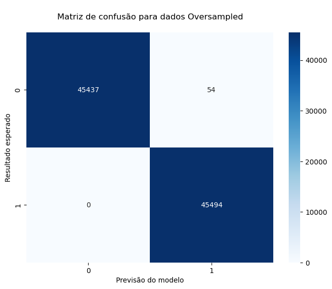

```python
matrix = confusion_matrix(y_test_oversampled, y_pred_oversampled)
plt.figure(figsize=(8, 6))
sns.heatmap(matrix, annot=True, fmt="d", cmap="Blues")
plt.xlabel('Previsão do modelo')
plt.ylabel('Resultado esperado')
plt.title('\nMatriz de confusão para dados Oversampled\n')
plt.show()
```

# Dados originais

#### Validando os modelos utilizando a base original

## Modelo do Undersampling

#### Resultado: Para a base original, o modelo classificou bem os casos de não fraude, mas olhando para os casos de fraude, o modelo não obteve o resultado esperado em relação ao que ele previu, acertando somente 5% do total previsto como fraude. A Acurácia ficou inviesada por conta da quantidade de acertos obtidos nos casos de não fraude, e por isso não é uma medida confiável neste caso.

```python
LGBMClassifier(modelo_under)
```

```
LGBMClassifier(boosting_type=LGBMClassifier(lambda_l1=2.013838835210629e-06,
                                            lambda_l2=0.0007771472931457983,
                                            learning_rate=0.007551211447829674,
                                            max_depth=41, min_child_weight=5,
                                            n_estimators=140, num_leaves=29,
                                            subsample=0.8750804543836551))
```

```python
y_pred_undersampled_original = modelo_under.predict(X_test_original)
```

```
[LightGBM] [Warning] lambda_l1 is set=2.013838835210629e-06, reg_alpha=0.0 will be ignored. Current value: lambda_l1=2.013838835210629e-06
[LightGBM] [Warning] lambda_l2 is set=0.0007771472931457983, reg_lambda=0.0 will be ignored. Current value: lambda_l2=0.0007771472931457983
```

```python
# Coletando as métricas de classificação obtidas
metricas = classification_report(y_test_original, y_pred_undersampled_original)
print(metricas)
```

```
              precision    recall  f1-score   support

           0       1.00      0.97      0.98     56853
           1       0.05      0.91      0.09       109

    accuracy                           0.97     56962
   macro avg       0.52      0.94      0.54     56962
weighted avg       1.00      0.97      0.98     56962
```

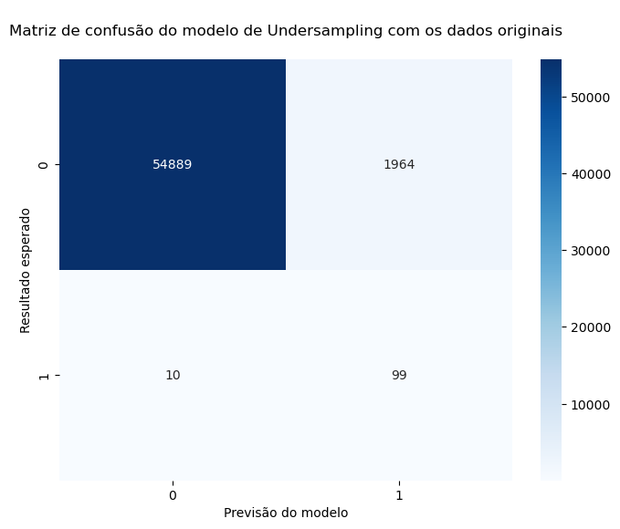

```python
matrix = confusion_matrix(y_test_original, y_pred_undersampled_original)
plt.figure(figsize=(8, 6))
sns.heatmap(matrix, annot=True, fmt="d", cmap="Blues")
plt.xlabel('Previsão do modelo')
plt.ylabel('Resultado esperado')
plt.title('\nMatriz de confusão do modelo de Undersampling com os dados originais\n')
plt.show()
```

## Modelo do Oversampling

```python
LGBMClassifier(modelo_over)
```

```
LGBMClassifier(boosting_type=LGBMClassifier(lambda_l1=0.3828821458483766,
                                            lambda_l2=0.00045100317062221715,
                                            learning_rate=0.04926240577582323,
                                            max_depth=35, min_child_weight=8,
                                            n_estimators=181, num_leaves=37,
                                            subsample=0.7316863020085818))
```

```python
y_pred_oversampled_original = modelo_over.predict(X_test_original)
```

```
[LightGBM] [Warning] lambda_l1 is set=0.3828821458483766, reg_alpha=0.0 will be ignored. Current value: lambda_l1=0.3828821458483766
[LightGBM] [Warning] lambda_l2 is set=0.00045100317062221715, reg_lambda=0.0 will be ignored. Current value: lambda_l2=0.00045100317062221715
```

```python
# Coletando as métricas de classificação obtidas
metricas = classification_report(y_test_original, y_pred_oversampled_original)
print(metricas)
```

```
              precision    recall  f1-score   support

           0       1.00      1.00      1.00     56853
           1       0.57      0.85      0.69       109

    accuracy                           1.00     56962
   macro avg       0.79      0.93      0.84     56962
weighted avg       1.00      1.00      1.00     56962
```

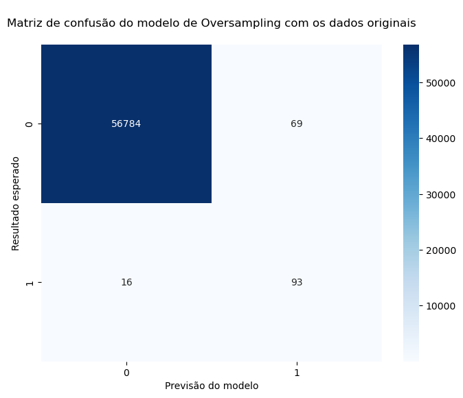

```python
matrix = confusion_matrix(y_test_original, y_pred_oversampled_original)
plt.figure(figsize=(8, 6))
sns.heatmap(matrix, annot=True, fmt="d", cmap="Blues")
plt.xlabel('Previsão do modelo')
plt.ylabel('Resultado esperado')
plt.title('\nMatriz de confusão do modelo de Oversampling com os dados originais\n')
plt.show()
```

# Conclusão

### Das metodologias de balanceamento de classes aplicadas, o Oversampling foi o que obteve o melhor modelo para ambas as classes.